# Assignment on linear models

Internet Initiative Japan Inc. has been chosen to complete the assignment.

The data is obtained from Google Finance for a period since 2009/01/01, each observation is a single day.

**All statistical assumptions and conclusions are made on the 5% significance level.**

The closing price is obtained the following way:

```r
library(quantmod)
stock = na.omit(Cl(getSymbols('IIJI', src='google', auto.assign=FALSE, from='2009-01-01')))
```

# Stationary AR models

## Task (a)

> Compute and plot the log price $x^t$ and the log return $r^t$. Comment on the two plots (how volatile the data are, volatility clustering, outliers etc).

```r
logst = log(stock)
logrt = na.omit(diff(logst))
```

The log price has an upward trend and can be considered pretty volatile. The series is non-stationary.

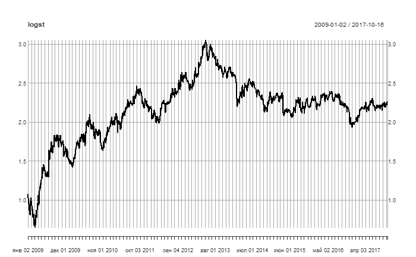

The log return series, however, does not has a trend, and most observations lie in the $[-0.1; 0.1]$ interval, though some outliers are present (at the start of the series and closer to the end).

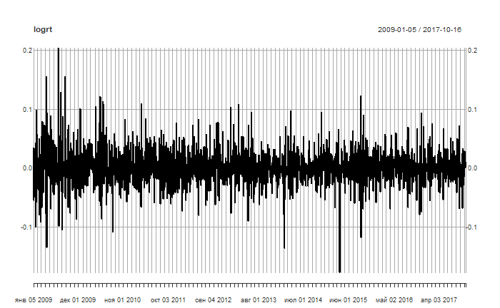

```r
plot(logrt)
```

## Task (b)

> Compute and plot the first 12 lags of ACF of $x^t$. Comment on the plot. Based on the ACF, is there a unit root in $x^t$ dataset? Why?

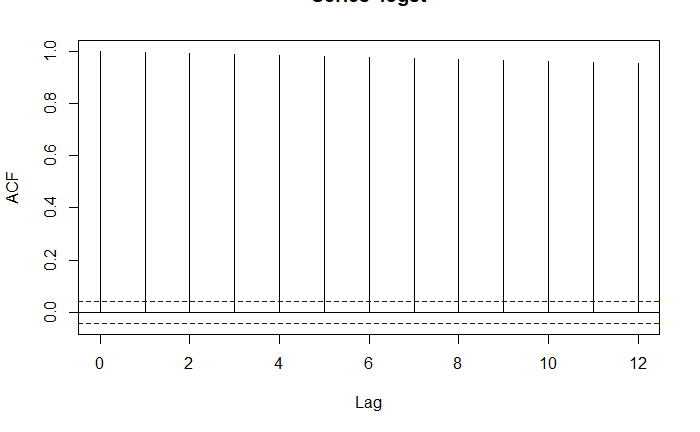

```r
acf(logst, lag=12)
```

The high ACF value of the first twelve lags indicates strong dependence on past observations and an existence of a unit root as ACF is very high (close to one) and decays to zero *exceptionally* slow. The series cannot be considered stationary.

## Task (c)

> Consider the time series for $r^t$. Perform the Ljung-Box test for m = 12. Draw a conclusion and justify it with the statistical language, i.e., in terms of the critical region or p-value.

```r
Box.test(as.numeric(logrt), lag=12, type='Ljung-Box')
```

```
    Box-Ljung test

data:  as.numeric(logrt)
X-squared = 21.788, df = 12, p-value = 0.03997
```

As $p$-value of the test is 0.03997 the null hypothesis should be rejected (because $p$-value < 0.05). In other words, the series exhibits autocorrelation for a number of lags equal to 12.

## Task (d)

> Use the command ar(rt,method=‘mle’,order.max=20) to specify the order of an AR model for rt. Use the PACF and AIC criteria (ar() and pacf() commands). Compare both approaches.

```r
ar_model = ar(as.numeric(logrt), method='mle', order.max=20)
ar_model
```

```
Call:
ar(x = as.numeric(logrt), order.max = 20, method = "mle")

Coefficients:
      1
-0.0763

Order selected 1  sigma^2 estimated as  0.0008473
```

```r
ar_model$aic
```

```
         0          1          2          3          4          5          6          7          8          9
10.6194291  0.0000000  0.4654660  0.6546984  2.3363099  3.8476919  5.1443749  6.2401481  6.7769394  8.4772810
        10         11         12         13         14         15         16         17         18         19
 9.6794496 10.1499213 12.0873770 14.0823852 11.3130233 13.2779143 15.2673553 16.0607454 18.0550180 19.2868185
        20
21.2850223
```

The minimum value of AIC is reached at the order 1 (meaning an $AR(1)$ model would be the best fit).

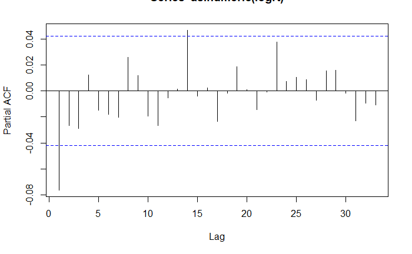

```r
pacf(as.numeric(logrt))
```

Both approaches yield the same result — an $AR(1)$ model.

## Task (e)

> Build an AR model for $r^t$. Plot the time series of the residuals, ACF and p-values of the Ljung-Box test (command tsdiag()). Perform the Ljung-Box test of the residuals by hand adjusting the degrees of freedom for the number of the model parameters (see [2], p.66). Is the model adequate? Why? Refine the model by eliminating all estimates with t-ratio less than 1.645 and check the new model as described above. Is the new model adequate? Why? Write down the final model.

```r
ar_model = arima(as.numeric(logrt), order=c(1,0,0))
ar_model
```

```
Call:
arima(x = as.numeric(logrt), order = c(1, 0, 0))

Coefficients:
          ar1  intercept
      -0.0763      6e-04
s.e.   0.0214      6e-04

sigma^2 estimated as 0.0008473:  log likelihood = 4580.83,  aic = -9155.66
```

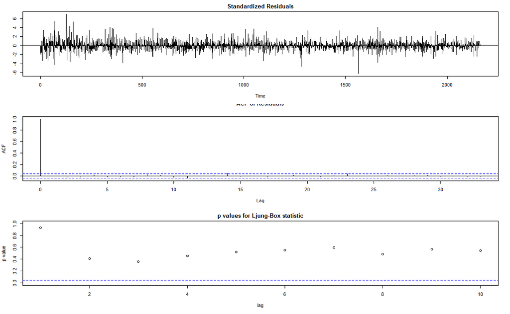

```r
Box.test(ar_model$residuals, lag=12, type='Ljung-Box')
```

```
    Box-Ljung test

data:  ar_model$residuals
X-squared = 10.414, df = 12, p-value = 0.5797
```

By performing the test the regular way the $p$-value was obtained.

```r
pv=1-pchisq(10.414, 11)
pv
```

```
[1] 0.4935764
```

Now the test statistic and $p$-value were adjusted to 11 degrees of freedom (since one $AR$ coefficient is used in the model). But even by adjusting the $p$-value, it is still high enough to not reject the null hypothesis of data not exhibiting autocorrelation.

where $ar_1$ denotes the first $AR$ variable.

## Task (f)

> Does the model imply existence of a cycle? Why? If the cycles are present, compute the average length of these cycles.

```r
r1
```

```
[1] -13.10572+0i
```

SInce all the roots are real numbers, the model does not imply existence of a cycle.

## Task (g)

> Use the fitted AR model to compute 1-step to 4-step ahead forecasts of rt at the forecast origin corresponding to the last observed date of the time series. Also, compute the corresponding 95% interval. Plot these results.

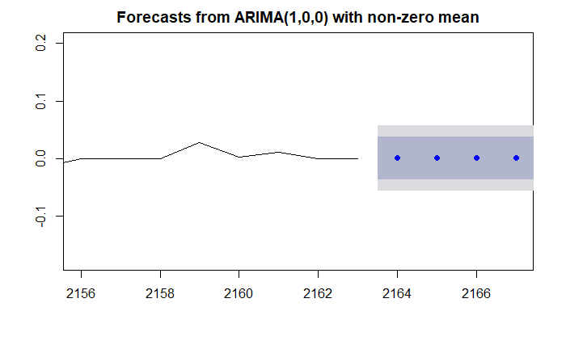

# MA model for $r^t$

## Task (a)

> Choose the order of such model. Support your choice with the ACF plot.

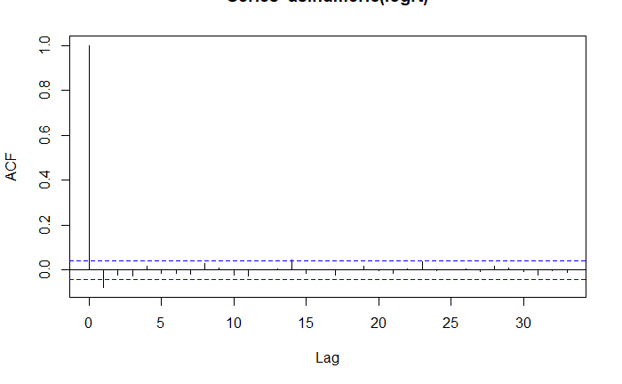

```r
acf(as.numeric(logrt))
```

## Task (b)

> Build the model. Refine it by removing coefficients estimates with t-ratio less than 1.645. Write down the fitted model.

```r
ma_model = arima(as.numeric(logrt), order=c(0,0,1))
ma_model
```

```
Call:
arima(x = as.numeric(logrt), order = c(0, 0, 1))

Coefficients:
          ma1  intercept
      -0.0806      5e-04
s.e.   0.0220      6e-04

sigma^2 estimated as 0.000847:  log likelihood = 4581.17,  aic = -9156.35
```

The final $MA$ model can be denoted as

where $ma_1$ denotes the first $MA$ variable.

## Task (c)

> Compute the Ljung-Box statistic of the residuals of the fitted MA model. Is there serial correlation in the residuals? Why?

```r
Box.test(ma_model$residuals, lag=12, type='Ljung-Box', fitdf = 1)
```

```
    Box-Ljung test

data:  ma_model$residuals
X-squared = 9.68, df = 11, p-value = 0.5594
```

The test statistic above is already adjusted to account for one moving average component (df = 11).

The $p$-value is high enough to not reject the null hypothesis, meaning the residuals are distributed independently. In other words, there is no serial correlation in the residuals.

## Task (d)

> Consider the in-sample fits of the AR model of Problem 1 and the MA model. Which model is preferred? Why?

The AIC of the $MA$-model is lower compared to the $AR$-model (-9156.346 versus -9155.661, respectively); thus, the MA model is preferable.

However, since the difference of the two values is miniscule, both models deal with the data almost the same way.

## Task (e)

> Use backtest at some forecast origin with horizon h = 1 to compare the two models. Indicate clearly the parameters of such backtesting (the estimation and forecasting subsamples, forecast origin and so on). Which model is preferred? Why?

```r
source("http://faculty.chicagobooth.edu/ruey.tsay/teaching/bs41202/sp2014/backtest.R")
bt = backtest(ar_model, as.numeric(logrt), 200, 1)
```

```
[1] "RMSE of out-of-sample forecasts"
[1] 0.0270693
[1] "Mean absolute error of out-of-sample forecasts"
[1] 0.01968851
```

```r
bt$rmse
```

```
[1] 0.0270693
```

```r
bt = backtest(ma_model, as.numeric(logrt), 200, 1)
```

```
[1] "RMSE of out-of-sample forecasts"
[1] 0.02706525
[1] "Mean absolute error of out-of-sample forecasts"
[1] 0.01968634
```

```r
bt$rmse
```

```
[1] 0.02706525
```

According to RMSE, $MA$ model predicts better, as such, it should be used for creating forecasts.

But again, the difference is even smaller and only appears in the sixth digit after the point.

# ARIMA model

> Yet again, focus on the log return series $r^t$ of the asset from Problem 1. Build an ARMA model including (a) Choosing the order of the model, (b) Writing down the model, (c) Checking the model for adequacy by analyzing the residuals, (d) Backtesting and comparing the model with those of Problems 1 and 2.

## Task (a)

```r
library(TSA)
eacf(logrt)
```

```
AR/MA
  0 1 2 3 4 5 6 7 8 9 10 11 12 13
0 x o o o o o o o o o o  o  o  x
1 x o o o o o o o o o o  o  o  x
2 x x o o o o o o o o o  o  o  x
3 x x x o o o o o o o o  o  o  o
4 x x x x o o o o o o o  o  o  o
5 x o x x o o o o o o o  o  o  o
6 x o x x o x o o o o o  o  o  o
7 x x x x x o x o o o o  o  o  o
```

## Task (b)

In the following line the model is built:

```r
arma_model = arima(logrt, order=c(1,0,1))
arma_model
```

```
Call:
arima(x = logrt, order = c(1, 0, 1))

Coefficients:
         ar1      ma1  intercept
      0.4257  -0.5019      5e-04
s.e.  0.2332   0.2227      5e-04

sigma^2 estimated as 0.0008462:  log likelihood = 4582.17,  aic = -9158.34
```

The model can be written as:

$$\begin{align}
y = 0.0005 + 0.4257 \times ar_1 - 0.5019 \times ma_1.
\end{align}$$

## Task (c)

```r
Box.test(arma_model$residuals, lag=12, type='Ljung-Box', fitdf = 2)
```

```
    Box-Ljung test

data:  arma_model$residuals
X-squared = 7.2073, df = 10, p-value = 0.7057
```

The $p$-value indicates that the null hypothesis cannot be rejected, meaning there is no autocorrelation in the residuals. As such, the model is adequate.

## Task (d)

```r
bt = backtest(arma_model, as.numeric(logrt), 200, 1)
```

```
possible convergence problem: optim gave code = 1
```

```
[1] "RMSE of out-of-sample forecasts"
[1] 0.02707333
[1] "Mean absolute error of out-of-sample forecasts"
[1] 0.01969358
```

```r
bt$rmse
```

```
[1] 0.02707333
```

Judging by RMSE metric, the $ARMA(1, 1)$ model is worse than $AR(1)$ and$MA(1)$ models.

But again, the difference only appears in the sixth digit after the decimal point.

# Daily range

> Consider the daily range (daily high minus daily low) of a “blue chip” stock (Apple, Coca- Cola etc.) for the last 4 years. Compute the first 100 lags of ACF of this series. Is there evidence of long-range dependence? Explain! If the range series has long memory, build an AFRIMA model for the data.

PepsiCo, Inc. was chosen as the blue chip stock

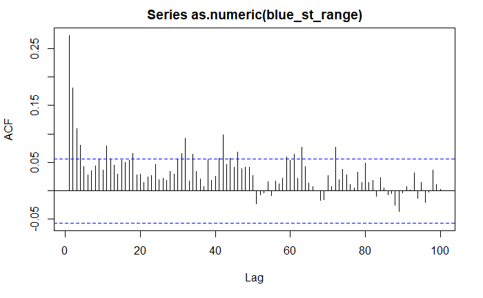

```r
blue_stock = na.omit(getSymbols('PEP', src='google', auto.assign=FALSE, from='2013-01-01'))
blue_st_range = blue_stock$PEP.High - blue_stock$PEP.Low
acf(as.numeric(blue_st_range), lag=100)
```

# ARCH effect

> Consider the log return series $r^t$ of the asset from Problem 1.

## Task (a)

> 1. Build an appropriate ARMA model.

The model was built earlier:

```r
arma_model
```

```
Call:
arima(x = logrt, order = c(1, 0, 1))

Coefficients:
         ar1      ma1  intercept
      0.4257  -0.5019      5e-04
s.e.  0.2332   0.2227      5e-04

sigma^2 estimated as 0.0008462:  log likelihood = 4582.17,  aic = -9158.34
```

## Task (b)

> 2. Test the residuals for the ARCH effect.

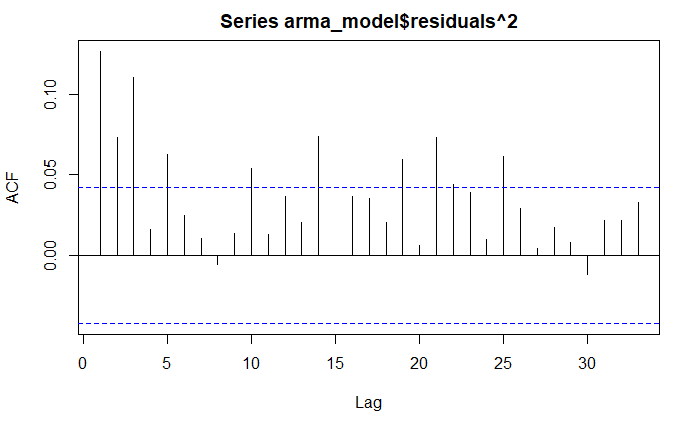

The residuals exhibit the ARCH effect.

## Task (c)

> 3. Fit an ARMA-GARCH Gaussian model to the data.

```r
library(fGarch)
garch_model = garchFit(~arma(1,1)+garch(1, 1), data=logrt, trace=FALSE)
```

```
possible convergence problem: optim gave code = 1
```

```r
garch_model
```

```
Title:
 GARCH Modelling

Call:
 garchFit(formula = ~arma(1, 1) + garch(1, 1), data = logrt, trace = FALSE)

Mean and Variance Equation:
 data ~ arma(1, 1) + garch(1, 1)
<environment: 0x0000000026553568>
 [data = logrt]

Conditional Distribution:
 norm

Coefficient(s):
         mu          ar1          ma1        omega       alpha1        beta1
 2.2751e-04   5.2329e-01  -5.9559e-01   1.7542e-05   3.1090e-02   9.4770e-01

Std. Errors:
 based on Hessian

Error Analysis:
         Estimate  Std. Error  t value Pr(>|t|)
mu      2.275e-04   2.979e-04    0.764   0.4451
ar1     5.233e-01   3.766e-01    1.390   0.1646
ma1    -5.956e-01   3.528e-01   -1.688   0.0914 .
omega   1.754e-05   7.406e-06    2.369   0.0179 *
alpha1  3.109e-02   7.972e-03    3.900 9.62e-05 ***
beta1   9.477e-01   1.530e-02   61.936  < 2e-16 ***
---
Signif. codes:  0 ‘***’ 0.001 ‘**’ 0.01 ‘*’ 0.05 ‘.’ 0.1 ‘ ’ 1

Log Likelihood:
 4642.583    normalized:  2.146363

Description:
 Wed Oct 18 01:10:50 2017 by user: koxre
```

## Task (d)

> 4. Check the model by analyzing standardized residuals.

```r
summary(garch_model)
```

```
Title:
 GARCH Modelling

Call:
 garchFit(formula = ~arma(1, 1) + garch(1, 1), data = logrt, trace = FALSE)

Mean and Variance Equation:
 data ~ arma(1, 1) + garch(1, 1)
<environment: 0x0000000026553568>
 [data = logrt]

Conditional Distribution:
 norm

Coefficient(s):
         mu          ar1          ma1        omega       alpha1        beta1
 2.2751e-04   5.2329e-01  -5.9559e-01   1.7542e-05   3.1090e-02   9.4770e-01

Std. Errors:
 based on Hessian

Error Analysis:
         Estimate  Std. Error  t value Pr(>|t|)
mu      2.275e-04   2.979e-04    0.764   0.4451
ar1     5.233e-01   3.766e-01    1.390   0.1646
ma1    -5.956e-01   3.528e-01   -1.688   0.0914 .
omega   1.754e-05   7.406e-06    2.369   0.0179 *
alpha1  3.109e-02   7.972e-03    3.900 9.62e-05 ***
beta1   9.477e-01   1.530e-02   61.936  < 2e-16 ***
---
Signif. codes:  0 ‘***’ 0.001 ‘**’ 0.01 ‘*’ 0.05 ‘.’ 0.1 ‘ ’ 1

Log Likelihood:
 4642.583    normalized:  2.146363

Description:
 Wed Oct 18 01:10:50 2017 by user: koxre


Standardised Residuals Tests:
                                Statistic p-Value
 Jarque-Bera Test   R    Chi^2  1425.148  0
 Shapiro-Wilk Test  R    W      0.9634854 0
 Ljung-Box Test     R    Q(10)  6.271473  0.7919628
 Ljung-Box Test     R    Q(15)  10.87696  0.7612667
 Ljung-Box Test     R    Q(20)  14.57031  0.8004441
 Ljung-Box Test     R^2  Q(10)  18.76191  0.04339306
 Ljung-Box Test     R^2  Q(15)  22.46362  0.09621142
 Ljung-Box Test     R^2  Q(20)  24.83226  0.207924
 LM Arch Test       R    TR^2   21.75693  0.0403361

Information Criterion Statistics:
      AIC       BIC       SIC      HQIC
-4.287178 -4.271424 -4.287193 -4.281417
```